# lab3

1. Obtain the Data: Get the Dogs vs Cats dataset (see CSCN8010 class notebook)
2. EDA: Explore the data with relevant graphs, statistics and insights

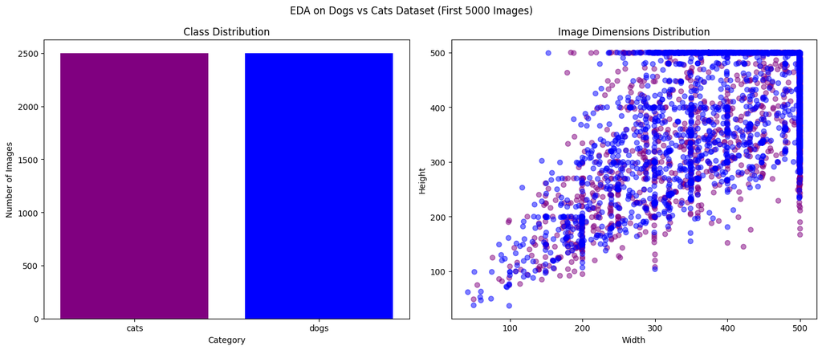

```
  Category     Width             Height
                mean min  max      mean min  max
0     cats  411.9864  50  500  357.4972  49  500
1     dogs  400.6440  42  500  365.1780  37  500
```

```python
import os
import matplotlib.pyplot as plt
from PIL import Image
import pandas as pd

# Define dataset directory
data_dir = "./train/train"

# Initialize counters for cats and dogs
data_stats = {'cats': {'count': 0, 'dimensions': []}, 'dogs': {'count': 0, 'dimensions': []}}

# Process 2,500 images each of cats and dogs
image_files = [f for f in os.listdir(data_dir) if f.endswith(('jpg', 'jpeg', 'png'))]
cats_count, dogs_count = 0, 0

for img_file in image_files:
    if 'cat' in img_file.lower() and cats_count < 2500:
        category = 'cats'
        cats_count += 1
    elif 'dog' in img_file.lower() and dogs_count < 2500:
        category = 'dogs'
        dogs_count += 1
    else:
        continue

    img_path = os.path.join(data_dir, img_file)
    try:
        with Image.open(img_path) as img:
            data_stats[category]['count'] += 1
            data_stats[category]['dimensions'].append(img.size)
    except:
        pass

# Convert dimensions to DataFrame for statistics
dimensions_df = pd.DataFrame([
    {"Category": cat, "Width": dim[0], "Height": dim[1]}
    for cat, stats in data_stats.items()
    for dim in stats['dimensions']
])

# Visualization and insights
fig, axes = plt.subplots(1, 2, figsize=(14, 6))
fig.suptitle("EDA on Dogs vs Cats Dataset (First 5000 Images)")

# Plot class distribution
class_counts = [data_stats[cat]['count'] for cat in ['cats', 'dogs']]
axes[0].bar(['cats', 'dogs'], class_counts, color=['purple', 'blue'])
axes[0].set_title('Class Distribution')
axes[0].set_ylabel('Number of Images')
axes[0].set_xlabel('Category')

# Plot image dimensions distribution
axes[1].scatter(dimensions_df['Width'], dimensions_df['Height'], alpha=0.5, c=dimensions_df['Category'].map({'cats': 'purple', 'dogs': 'blue'}))
axes[1].set_title('Image Dimensions Distribution')
axes[1].set_xlabel('Width')
axes[1].set_ylabel('Height')

plt.tight_layout()
plt.show()

# Statistics summary for image dimensions
dimension_summary = dimensions_df.groupby('Category').agg({
    'Width': ['mean', 'min', 'max'],
    'Height': ['mean', 'min', 'max']
}).reset_index()

print(dimension_summary)
```

3. Train two networks (use callbacks to save the best model version):

a. Define a Neural Network of your choice

b.Fine-Tune VGG16 (pre-trained on imagenet). Make sure to use validation to test for over-fitting. Plot the appropriate graph

```
Found 20000 images belonging to 2 classes.
Found 5000 images belonging to 2 classes.
Training samples: 20000
Validation samples: 5000
Training Custom CNN...
```

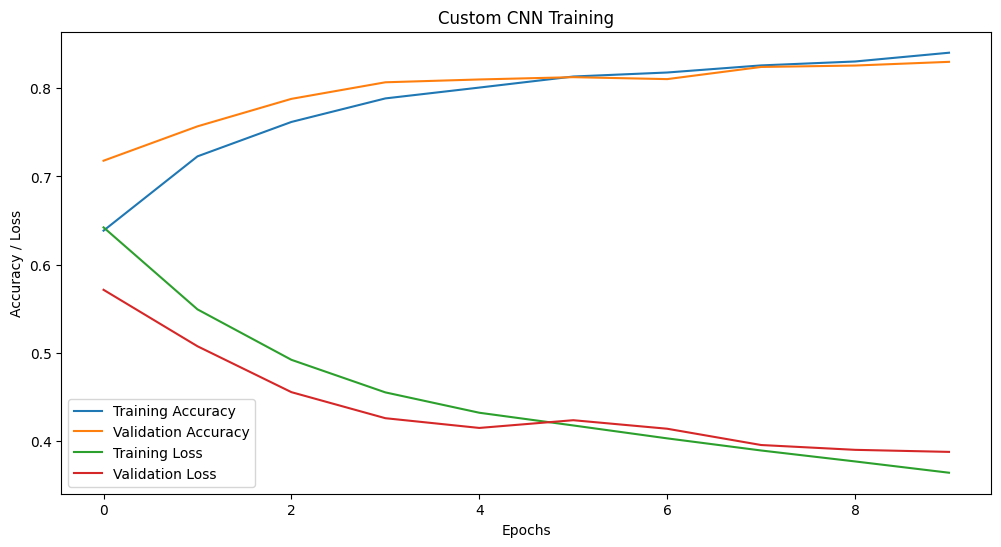

```
Training Fine-Tuned VGG16...
```

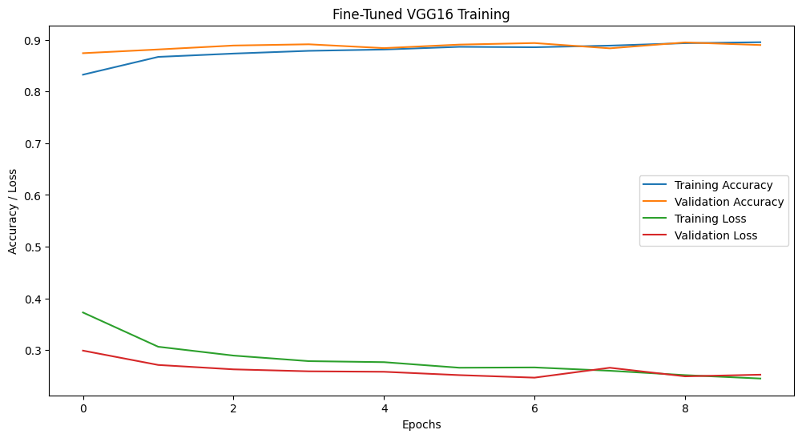

```python
import os
import tensorflow as tf
from tensorflow.keras.models import Sequential, Model
from tensorflow.keras.layers import Conv2D, MaxPooling2D, Flatten, Dense, Dropout, Input
from tensorflow.keras.preprocessing.image import ImageDataGenerator
from tensorflow.keras.applications import VGG16
from tensorflow.keras.callbacks import ModelCheckpoint, EarlyStopping
import matplotlib.pyplot as plt
from tensorflow.keras.utils import image_dataset_from_directory

# Set constants
IMAGE_SIZE = (128, 128)
BATCH_SIZE = 32
EPOCHS = 10
DATA_DIR = "./train/train"
VALIDATION_SPLIT = 0.2

# Helper function to preprocess filenames into subfolders
def organize_dataset(data_dir):
    organized_dir = "./organized_dataset"
    os.makedirs(organized_dir, exist_ok=True)
    for file in os.listdir(data_dir):
        if "cat" in file.lower():
            category = "cats"
        elif "dog" in file.lower():
            category = "dogs"
        else:
            continue
        category_dir = os.path.join(organized_dir, category)
        os.makedirs(category_dir, exist_ok=True)
        os.rename(os.path.join(data_dir, file), os.path.join(category_dir, file))
    return organized_dir

# Organize files into separate directories for cats and dogs
ORGANIZED_DIR = organize_dataset(DATA_DIR)

# Data Generators
datagen = ImageDataGenerator(
    rescale=1./255,
    validation_split=VALIDATION_SPLIT,
    shear_range=0.2,
    zoom_range=0.2,
    horizontal_flip=True
)

train_gen = datagen.flow_from_directory(
    ORGANIZED_DIR,
    target_size=IMAGE_SIZE,
    batch_size=BATCH_SIZE,
    class_mode='binary',
    subset='training'
)

val_gen = datagen.flow_from_directory(
    ORGANIZED_DIR,
    target_size=IMAGE_SIZE,
    batch_size=BATCH_SIZE,
    class_mode='binary',
    subset='validation'
)

# Debugging: Check if data is loaded
print(f"Training samples: {train_gen.samples}")
print(f"Validation samples: {val_gen.samples}")

# Add an assertion to catch empty generators early
assert train_gen.samples > 0, "No training data found. Check dataset directory."
assert val_gen.samples > 0, "No validation data found. Check dataset directory."

# Callback to save the best model
checkpoint = ModelCheckpoint('best_model.h5', monitor='val_loss', save_best_only=True, mode='min')
early_stopping = EarlyStopping(monitor='val_loss', patience=3, restore_best_weights=True)

# Helper function to plot training history
def plot_training_history(history, title):
    plt.figure(figsize=(12, 6))
    plt.plot(history.history['accuracy'], label='Training Accuracy')
    plt.plot(history.history['val_accuracy'], label='Validation Accuracy')
    plt.plot(history.history['loss'], label='Training Loss')
    plt.plot(history.history['val_loss'], label='Validation Loss')
    plt.title(title)
    plt.xlabel('Epochs')
    plt.ylabel('Accuracy / Loss')
    plt.legend()
    plt.show()


# --- Model 1: Custom CNN ---
custom_cnn = Sequential([
    Conv2D(32, (3, 3), activation='relu', input_shape=(128, 128, 3)),
    MaxPooling2D((2, 2)),
    Conv2D(64, (3, 3), activation='relu'),
    MaxPooling2D((2, 2)),
    Flatten(),
    Dense(128, activation='relu'),
    Dropout(0.5),
    Dense(1, activation='sigmoid')
])

custom_cnn.compile(optimizer='adam', loss='binary_crossentropy', metrics=['accuracy'])

print("Training Custom CNN...")
history_cnn = custom_cnn.fit(
    train_gen,
    epochs=EPOCHS,
    validation_data=val_gen,
    callbacks=[checkpoint, early_stopping]
)
plot_training_history(history_cnn, "Custom CNN Training")

# --- Model 2: Fine-Tuned VGG16 ---
vgg_base = VGG16(weights='imagenet', include_top=False, input_tensor=Input(shape=(128, 128, 3)))

# Freeze all convolutional layers in VGG16
for layer in vgg_base.layers:
    layer.trainable = False

# Add custom classification layers on top of VGG16
x = Flatten()(vgg_base.output)
x = Dense(128, activation='relu')(x)
x = Dropout(0.5)(x)
output = Dense(1, activation='sigmoid')(x)

vgg_model = Model(inputs=vgg_base.input, outputs=output)
vgg_model.compile(optimizer='adam', loss='binary_crossentropy', metrics=['accuracy'])

print("Training Fine-Tuned VGG16...")
history_vgg = vgg_model.fit(
    train_gen,
    epochs=EPOCHS,
    validation_data=val_gen,
    callbacks=[checkpoint, early_stopping]
)
plot_training_history(history_vgg, "Fine-Tuned VGG16 Training")
```

4. Explore the relative performance of the models (make sure to load the best version of each model):

a. accuracy